# OptimModel Vignette

Steven Novick

2025-05-04

# Introduction

The R package OptimModel provides various nonlinear (or linear) curve-fitting functions that use `stats::optim()` as its base. The packages contains many commonly-used curves and also permits the user to create a new curve function as well. To estimate curve parameters, the user may call upon ordinary least squares (OLS), weighted least squares (WLS), iterative reweighted least squares (IRWLS), or maximum likelihood estimate (MLE). For WLS, the user provides a fixed set of weights. For IRWLS and MLE, the user may choose among a variety of weight functions. Finally, there is also a function for robust outlier detection (ROUT), based on the work of Motulsky and Brown (2006).

# Pre-specified models

In the OptimModel package, data are assumed to stem from the model

$$y_i = f(\boldsymbol{\theta}, x_i) +
e_i, i = 1, \ldots, n$$
where $x_i$ is a concentration or dose, $y_i$ is the response, $\boldsymbol{\theta}$ is a vector of mean-model parameters, and $e_i \sim N(0, \sigma^2 g^2(\boldsymbol{\theta}, \boldsymbol{\phi}))$. The mean of $y_i | x_i$ is $f(\boldsymbol{\theta}, x_i)$ and the variance is $\sigma^2 g^2(\boldsymbol{\theta}, \boldsymbol{\phi}))$ with variance-model parameters $\boldsymbol{\phi}$. The default is $g(\boldsymbol{\theta}, \boldsymbol{\phi}) = 1$ so that $e_i \sim N(0, \sigma^2)$. The user, however, may instead provide non-negative valued numerical weights $\{w_1, \ldots, w_n \}$ so that $e_i \sim N(0, \sigma^2 \sqrt{w_i})$.

A number of pre-defined models for the mean and variance are provided in OptimModel. User-defined mean models and/or variance models may be supplied to the main function, optim_fit().

## Mean-model functions

Mean models are functions of the form $f(\theta, x)$, where $\theta$ is a parameter vector and $x$ is an R object that is processed by the function. Usually $x$ is a vector of doses or concentrations; however, $x$ may also be a matrix, data.frame, or list. Examples of user-defined mean models are provided at the end of this section.

Although it is not a requirement, each of the mean-model functions included in OptimModel is given several attributes, shown in the table below, where f_model takes the place of the model function.

| Attribute | Purpose |
| --- | --- |
| attr(f_model, ‘gradient’) | Gradient of f_model with respect to theta |
| attr(f_model, ‘backsolve’) | Find x such that f_model(theta, x) = y |
| attr(f_model, ‘start’) | Starting values for optimization |

If attr(f_model, ‘gradient’) is missing, the gradient of f_model will be approximated. If attr(f_model, ‘start’) is missing, the user must supply a starting value.

### Exponential decay (first order)

The first-order exponential decay model is given by
$$f(\boldsymbol{\theta}, x) = A + B \times exp(-K
x),$$
where $x$ is the concentration or dose, $\boldsymbol{\theta} = (A, B, lK)$, $A$ is the minimum value, $A+B$ is the maximum value, and $K=exp(lK)$ is the shape parameter.

## Exponential decay (first order) with plateau

The first-order exponential decay model with plateau is an extension of the exponential decay model and given as $f(\boldsymbol{\theta}, x) = y_{max}$ if $x \le X_0$ and $f(\boldsymbol{\theta}, x) = y_{min} + (y_{max} - y_{min}) \times exp(-K (x-X0))$ if $x > X_0$, where $\boldsymbol{\theta} = (x_0, y_{min}, y_{max}, lK)$, $X_0=exp(x_0)$ is the inflection point between plateau and exponential decay curve, $y_{min}$ is the minimum value, $y_{max}$ is the maximum value, and $K=exp(lK)$ is the shape parameter.

## Exponential decay (second order)

The second-order exponential decay model is given by
$$f(\boldsymbol{\theta}, x) = A + B \times \{ p
\times \exp(-K_1 x) + (1-p) \times \exp(-K_2 x) \},$$
where $x$ is the concentration or dose, $\boldsymbol{\theta} = (A, B, lK_1, lK_2, p)$, $A$ is the minimum value, $A+B$ is the maximum value, $K_1=exp(lK_1)$ and $K_2 = exp(lK_2)$ are shape parameters, and $p$ is the proportion of signal from the first exponential term.

### Gompertz model

The four-parameter Gompertz model is a sigmoidal shaped curve, given by

$$f(\boldsymbol{\theta}, x) = A + (B -
A)\times \exp( -\exp( m*(x- x_0)) ),$$
where $x$ is the concentration or dose, $\boldsymbol{\theta} = (A, B, m, x_0)$, $A$ is the minimum value, $A + (B-A)\times exp(-exp(-m x_0 ))$ is the maximum value, $m$ is the shape parameter, and $x_0$ is an offset that shifts the curve on the $x$-axis.

### Four-parameter Hill (4PL) model

The Hill equation (Hill, 1910), which is equivalent to the four-parameter logistic curve (Verhulst, 1845), is a sigmoidal-shaped curve with meaningful parameters. The mean model is

$$f(\boldsymbol{\theta}, x) = e_{min} +
\frac{e_{max} - e_{min}}{ 1 + \exp( m \times( lec50 - log(x) ) )},$$
where $x$ is the concentration or dose, $\boldsymbol{\theta}=(e_{min}, e_{max}, lec50, m)$, $e_{min}$ is the minimum asymptote, $e_{max}$ is the maximum asymptote, $lec50$ is the natural log EC50, and $m$ is the shape parameter. Note that $f(\boldsymbol{\theta}, EC50) = \frac{1}{2}( e_{min} + e_{max})$ and $m$ is often called the *slope* or *Hill* parameter. Refer to Hill (1910) or Verhulst (1845) for more information.

### Five-parameter Hill model

The 5-parameter Hill equation is an extension of the 4-parameter model that is asymmetric around the EC50. The model is given by

$$f(\boldsymbol{\theta}, x) = e_{min} +
\frac{e_{max} - e_{min}}{ \{1 + exp( m \times( lec50 - log(x) ) )\}^s},$$
where $x$ is the concentration or dose, $\boldsymbol{\theta}=(e_{min}, e_{max}, lec50, m, ls)$, $e_{min}$ is the minimum asymptote, $e_{max}$ is the maximum asymptote, $lec50$ is the natural log EC50, $m$ is the shape parameter, and $s=exp(ls)$ is the symmetry parameter. Note that $f(\boldsymbol{\theta}, EC50) = \frac{1}{2^s}( e_{min} + e_{max})$ and $m$ is often called the *slope* or *Hill* parameter.

### Hill quadratic model

The Hill model with a quadratic term is a five-parameter equation for biphasic data. The mean model is given by

$$f(\boldsymbol{\theta}, x) = e_{min} +
\frac{e_{max} - e_{min}}{ \{1 + exp( -\{a + b z + c z^2 \})},$$
where $z=log(x)$, $x$ is the concentration or dose, $\boldsymbol{\theta}=(e_{min}, e_{max}, a, b, c)$, $e_{min}$ is the minimum asymptote, $e_{max}$ is the maximum asymptote, and $(a, b, c)$ are respectively the intercept, linear, and quadratic terms.

Note that if $c = 0$, this model is equivalent to the four-parameter Hill model (hill.model). Also, the $EC50$ is defined where $a + b z + c z^2 = 0$. If the roots of the quadratic equation are real, then the $EC50$ is given by $(-b +/- \sqrt{b^2 - 4 a c})/(2 c)$. The user decides which of the roots is meaningful.

### Hill switchpoint model

The Hill switchpoint is a biphasic equation that extends the four-parameter Hill model. The mean model is

$$f(\boldsymbol{\theta}, x) = e_{min} +
\frac{e_{max} - e_{min}}{ 1 + exp( m f(s, x) \times( lec50 - log(x) )
)},$$
where $x$ is the concentration or dose, $\boldsymbol{\theta}=(e_{min}, e_{max}, lec50, m, ls)$, $e_{min}$ is the minimum asymptote, $e_{max}$ is the maximum asymptote, $lec50$ is the natural log EC50, and $m$ is the shape parameter. Note that $f(\boldsymbol{\theta}, EC50) = \frac{1}{2}( e_{min} + e_{max})$ and $m$ is often called the *slope* or *Hill* parameter.

### Beta model

The Beta model is a biphasic curve based on the Beta function. Found in `MCPMod::betaMod()`, the curve is given by

$$f(\boldsymbol{\theta}, x) = e_{min} +
e_{max} \times exp \left( log\{ \beta(\delta_1, \delta_2) \} +
\delta_1 \times log(x) + \delta_2 \times log(sc - x) - (\delta_1 +
\delta_2) \times log(sc) \right),$$
where $\beta(\delta_1, \delta_2) = (\delta_1+\delta_2)^{(\delta_1+\delta_2)} / ( \delta_1^{\delta_1} \times \delta_2^{\delta^2} )$, $e_{min}$ is a lower aymptote, $e_{max}$ is an upper asymptote, $sc$ is a scaling parameter, and $\delta_1$ and $\delta_2$ are power parameters.

### User defined mean model

An example of a user-defined mean model is from simple linear regression. Code is provided below in which theta = c( intercept, slope ) and $x$ is a vector.

```
slr_model = function(theta, x){  theta[1] + theta[2]*x }

theta = c( 2, -5 )   ## Intercept, slope
x = seq(1, 10, by=0.5)
slr_model(theta, x)
```

The next example shows $x$ as a matrix for multivariate linear regression.

```
mlr_model = function(theta, x){  theta[1] + theta[2]*x[,1] + theta[3]*x[,2] }

theta = c( 2, -5, 0.1 )   ## Intercept, slope1, slope2
x1 = seq(1, 10, by=0.5)
x2 = seq(10, 1, by=-0.5)
mlr_model(theta, x=cbind(x1, x2))
```

## Weight/Variance functions

The package OptimModel also provides several pre-defined weight/variance functions. The default function is weights_varIdent(), which sets $g(\boldsymbol{\theta}, \boldsymbol{\phi}) = 1$ for all observations (i.e., no weights). The user has no reason to call weights_varIdent().

The following table shows the forms of $g(\boldsymbol{\theta}, \boldsymbol{\phi})$ for pre-defined functions, where $mu = f(\boldsymbol{\theta}, x)$ and $resid = y - mu$.

| Function | Code |
| --- | --- |
| weights_varIdent(phi, mu) | rep(1, length(mu)) |
| weights_varExp(phi, mu) | exp(phi*mu) |
| weights_varPower(phi, mu) | abs(mu)^(phi) |
| weights_varConstPower(phi, mu) | phi[1]+abs(mu)^(phi[2]) |
| weights_tukey_bw(phi=4.685, resid) | see below |
| weights_huber(phi=1.345, resid) | see below |

### Tukey bi-weight

The weight function is $w = (1-(r/\phi)^2)^2$ if $r \le \phi$ and $w=0$ otherwise, where $r = |resid|/sig$ and sig = mad(resid, center=0). Traditionally, $phi = 4.685$.

### Huber weights

The weight function is $w = min(1, \phi / r)$, where $r = |resid|/sig$ and sig = mad(resid, center=0). Traditionally, $phi = 1.345$. This is also the default weight used in `MASS::rlm()`.

### User-defined weights

The user may provide a weight function with arguments *phi* and *mu*. For example,

```
weights_user1 = function(phi, mu){  ifelse( mu < 5, (1/mu), (1/mu)^phi ) }

mu = 1:10
phi = 2.4
weights_user1(phi, mu)
```

## Calling optim_fit

Usage of the optim_fit() function will be illustrated with a data set generated from the hill_model(). An optim_fit() object is associated with S3-type functionality for *print*, *fitted*, and *residuals*.

### OLS and WLS

Data are generated from hill_model(). For OLS and WLS, the call to optim_fit() is bare boned. The print.optim_fit() function provides parameter estimates, standard errors, and 95% confidence intervals. It also provides the rMSE (sigma), an $r^2$ value, and BIC value.

```r
library(OptimModel)
set.seed(456)
x = rep( c(0, 2^(-4:4)), each=4 )
theta = c(0, 100, log(.5), 2)
y = hill_model(theta, x) + rnorm( length(x), sd=2 )

  ## No need to include a starting value.
fit = optim_fit(theta0=NULL, f.model=hill_model, x=x, y=y)
print(fit)
```

```
#>
#> Fit method = 'ols'
#> Variance computation method = 'hessian'
#> Weights = weights_varIdent
#> Convergence : Achieved
#>
#> 95% Wald CI for parameters
#>       par     standard.error lower   upper
#> emin  -0.0458 0.5974         -1.2574   1.1658
#> emax  99.2786 0.6993         97.8603 100.6969
#> lec50 -0.6503 0.0184         -0.6877  -0.6130
#> m      2.1594 0.0774          2.0024   2.3165
#> sigma = 2.0426 on 36 degrees of freedom
#> r-squared = 0.9979
#> BIC =  184.8841   (smaller is better)
```

```r
## Coefficients
coef(fit)
```

```
#>        emin        emax       lec50           m
#> -0.04582586 99.27856807 -0.65033795  2.15943681
```

```r
## Fitted values
fitted(fit)
```

```
#>  [1] 99.27856807 99.27856807 99.27856807 99.27856807 98.27320258 98.27320258
#>  [7] 98.27320258 98.27320258 94.93948372 94.93948372 94.93948372 94.93948372
#> [13] 82.44415089 82.44415089 82.44415089 82.44415089 51.91021938 51.91021938
#> [19] 51.91021938 51.91021938 19.53345242 19.53345242 19.53345242 19.53345242
#> [25]  5.12854738  5.12854738  5.12854738  5.12854738  1.16123128  1.16123128
#> [31]  1.16123128  1.16123128  0.22693902  0.22693902  0.22693902  0.22693902
#> [37]  0.01536124  0.01536124  0.01536124  0.01536124
```

```r
## Residuals
residuals(fit)
```

```
#>  [1] -1.965610882  1.964983041  2.323181264 -2.056352891 -1.240377833
#>  [6] -0.459786220  1.569621876  0.689431687  1.192867878  0.324632706
#> [11] -2.653457701  1.800358234 -0.466698260  0.863706482 -5.325761356
#> [16]  1.450561979  1.563652969 -1.135252733  2.649848560  1.165547240
#> [21] -0.482660037 -2.968070025 -2.387113040  0.883019419  0.682133203
#> [26]  3.022374689 -0.171904379  0.097037498  3.346309206 -1.801525553
#> [31] -0.680358172 -0.810355452 -3.835665264  0.754472293  0.503416542
#> [36]  3.793470677 -1.239006478 -0.198304151 -0.765758483  0.004728182
#> attr(,"label")
#> [1] "Residuals"
```

The predict() function may be used to obtain mean-model estimates at specific *x* values. It may also provide standard errors, confidence intervals, and prediction intervals. A graph of the data with 95% confidence bands is provided.

```r
predict(fit, x=2:5)
```

```
#>      x     y.hat
#> [1,] 2 5.1285474
#> [2,] 3 2.1775014
#> [3,] 4 1.1612313
#> [4,] 5 0.7031703
```

```r
predict(fit, x=2:5, se.fit=TRUE)
```

```
#>      x     y.hat    se.fit
#> [1,] 2 5.1285474 0.5130136
#> [2,] 3 2.1775014 0.4853637
#> [3,] 4 1.1612313 0.5104829
#> [4,] 5 0.7031703 0.5326739
```

```r
## 95% confidence interval
predict(fit, x=2:5, interval="confidence")
```

```
#>      x     y.hat    se.fit      lower    upper
#> [1,] 2 5.1285474 0.5130136  4.0881076 6.168987
#> [2,] 3 2.1775014 0.4853637  1.1931383 3.161864
#> [3,] 4 1.1612313 0.5104829  0.1259241 2.196538
#> [4,] 5 0.7031703 0.5326739 -0.3771424 1.783483
```

```r
## 90% confidence interval
predict(fit, x=2:5, interval="confidence", level=0.9)
```

```
#>      x     y.hat    se.fit      lower    upper
#> [1,] 2 5.1285474 0.5130136  4.2624277 5.994667
#> [2,] 3 2.1775014 0.4853637  1.3580630 2.996940
#> [3,] 4 1.1612313 0.5104829  0.2993843 2.023078
#> [4,] 5 0.7031703 0.5326739 -0.1961418 1.602482
```

```r
## 95% prediciton interval for next observation (K=1)
predict(fit, x=2:5, interval="prediction", K=1)
```

```
#>      x     y.hat    se.fit      lower    upper
#> [1,] 2 5.1285474 0.5130136  0.8572438 9.399851
#> [2,] 3 2.1775014 0.4853637 -2.0804899 6.435493
#> [3,] 4 1.1612313 0.5104829 -3.1088250 5.431288
#> [4,] 5 0.7031703 0.5326739 -3.5780205 4.984361
```

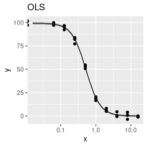

```r
d = data.frame(x=x, y=y)
pred = as.data.frame(predict(fit, x=2^seq(-6, 4, length=25), interval="confidence"))

library(ggplot2)
ggplot( d, aes(x=x, y=y) ) + geom_point() +
  geom_line( data=pred, aes(x, y.hat)) +
  geom_ribbon( data=pred, aes(x=x, y=y.hat, ymin=lower, ymax=upper), alpha=0.3) +
  scale_x_log10() + ggtitle("OLS")
```

```r
## Fixed weights.  In this example, weights are increasing step-wise with x
w = ifelse(x < 0.1, 0.5, ifelse(x < 2, 1, 2))
  ## No need to include a starting value.
fit = optim_fit(theta0=NULL, f.model=hill_model, x=x, y=y, wts=w)
print(fit)
```

```
#>
#> Fit method = 'ols'
#> Variance computation method = 'hessian'
#> Weights = user.defined
#> Convergence : Achieved
#>
#> 95% Wald CI for parameters
#>       par     standard.error lower   upper
#> emin  -0.0430 0.5042         -1.0655   0.9796
#> emax  99.3303 1.0216         97.2584 101.4022
#> lec50 -0.6496 0.0220         -0.6942  -0.6049
#> m      2.1396 0.0862          1.9648   2.3145
#> sigma = 2.333 on 36 degrees of freedom
#> r-squared = 0.9978
#> BIC =  189.9727   (smaller is better)
```

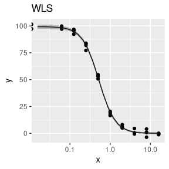

```r
pred = as.data.frame(predict(fit, x=2^seq(-6, 4, length=25), interval="confidence"))

ggplot( d, aes(x=x, y=y) ) + geom_point() +
  geom_line( data=pred, aes(x, y.hat)) +
  geom_ribbon( data=pred, aes(x=x, y=y.hat, ymin=lower, ymax=upper), alpha=0.3) +
  scale_x_log10() + ggtitle("WLS")
```

### MLE

The same curve may be fitted to the data via maximum likelihood. In the following code output, note that the starting value needs to include log of the standard deviation (‘lsigma’) as the last parameter.

```r
fit = optim_fit(theta0=NULL, f.model=hill_model, x=x, y=y, fit.method="mle")
print(fit)
```

```
#>
#> Fit method = 'mle'
#> Variance computation method = 'hessian'
#> Weights = weights_varIdent
#> Convergence : Achieved
#>
#> 95% Wald CI for parameters
#>        par     standard.error lower   upper
#> emin   -0.0458 0.5668         -1.1566   1.0651
#> emax   99.2788 0.6634         97.9785 100.5791
#> lec50  -0.6503 0.0175         -0.6846  -0.6161
#> m       2.1594 0.0735          2.0155   2.3034
#> lsigma  0.6616 0.1118          0.4424   0.8807
#> sigma = 1.9378 on Inf degrees of freedom
#> r-squared = 0.9979
#> BIC =  188.573   (smaller is better)
#> var/weight param(s):
#> [1] none
```

Maximum likelihood can also be used with variance model functions. The following code illustrates the method with a power-of-the-mean variance model (weights_varPower) with $\sigma=0.7$ and $\phi = 0.5$.

```r
set.seed(876)

## Standard deviation = sigma*( Mean )^0.5
y2 = hill_model(theta, x) + rnorm( length(x), sd=0.7*sqrt(hill_model(theta, x)) )


fit = optim_fit(theta0=NULL, f.model=hill_model, x=x, y=y2, wts=weights_varPower,
                fit.method="mle", phi.fixed=FALSE)
print(fit)
```

```
#>
#> Fit method = 'mle'
#> Variance computation method = 'hessian'
#> Weights = weights_varPower
#> Convergence : Achieved
#>
#> 95% Wald CI for parameters
#>        par      standard.error lower   upper
#> emin    -0.3626 0.1237         -0.6050  -0.1202
#> emax   102.9510 1.7656         99.4906 106.4114
#> lec50   -0.7299 0.0383         -0.8049  -0.6549
#> m        1.8806 0.0775          1.7286   2.0326
#> v1       0.4190 0.0426          0.3355   0.5024
#> lsigma  -0.2895 0.1543         -0.5919   0.0128
#> sigma = 0.7486 on Inf degrees of freedom
#> r-squared = 0.9997
#> BIC =  196.694   (smaller is better)
#> var/weight param(s):
#>   phi
#> 0.419
```

### IRWLS

The same variance model may be fitted to the data using iterative reweighted least squares.

```r
fit = optim_fit(theta0=NULL, f.model=hill_model, x=x, y=y2, wts=weights_varPower,
                fit.method="irwls", phi.fixed=FALSE)
print(fit)
```

```
#>
#> Fit method = 'irwls'
#> Variance computation method = 'hessian'
#> Weights = weights_varPower
#> Convergence : Achieved
#>
#> 95% Wald CI for parameters
#>       par      standard.error lower   upper
#> emin    0.0502 0.1314         -0.2162   0.3166
#> emax  102.4983 1.8791         98.6872 106.3094
#> lec50  -0.7251 0.0401         -0.8065  -0.6437
#> m       1.9330 0.0773          1.7763   2.0897
#> sigma = 0.6392 on 36 degrees of freedom
#> r-squared = 0.9998
#> BIC =  186.3115   (smaller is better)
#> var/weight param(s):
#>    phi
#> 0.4714
```

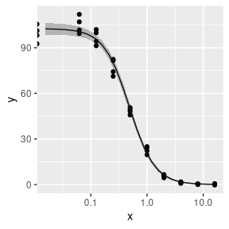

```r
d = data.frame(x=x, y=y2)
pred = as.data.frame(predict(fit, x=2^seq(-6, 4, length=25), interval="confidence"))

ggplot( d, aes(x=x, y=y) ) + geom_point() +
  geom_line( data=pred, aes(x, y.hat)) +
  geom_ribbon( data=pred, aes(x=x, y=y.hat, ymin=lower, ymax=upper), alpha=0.3) +
  scale_x_log10()
```

### Robust model fit

Iterative reweighted least squares may be implemented with a robust weighting scheme, such as Huber weighting, to down-weight outliers. With OLS, the curve gets pulled slightly downward by the outliers, but with the Huber weighting, the outliers are virtually ignored.

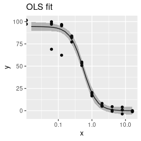

```r
set.seed(456)
x = rep( c(0, 2^(-4:4)), each=4 )
theta = c(0, 100, log(.5), 2)
y = hill_model(theta, x) + rnorm( length(x), sd=2 )

## Create outliers
y[c(8, 11)] = y[c(8, 11)] + -30

## Ordinary least squares
fit = optim_fit(theta0=NULL, f.model=hill_model, x=x, y=y)


d = data.frame(x=x, y=y)
pred = as.data.frame(predict(fit, x=2^seq(-6, 4, length=25), interval="confidence"))

ggplot( d, aes(x=x, y=y) ) + geom_point() +
  geom_line( data=pred, aes(x, y.hat)) +
  geom_ribbon( data=pred, aes(x=x, y=y.hat, ymin=lower, ymax=upper), alpha=0.3) +
  scale_x_log10() + ggtitle("OLS fit")
```

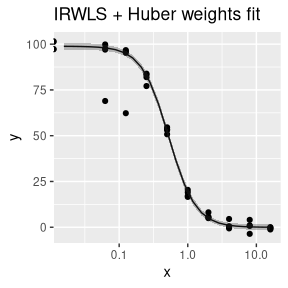

```r
## IRWLS with Huber weights
fit = optim_fit(theta0=NULL, f.model=hill_model, x=x, y=y, wts=weights_huber,
                fit.method="irwls")

d = data.frame(x=x, y=y)
pred = as.data.frame(predict(fit, x=2^seq(-6, 4, length=25), interval="confidence"))

ggplot( d, aes(x=x, y=y) ) + geom_point() +
  geom_line( data=pred, aes(x, y.hat)) +
  geom_ribbon( data=pred, aes(x=x, y=y.hat, ymin=lower, ymax=upper), alpha=0.3) +
  scale_x_log10() + ggtitle("IRWLS + Huber weights fit")
```